**Time-Series Analysis**

By Prof. Seungchul Lee  
http://iailab.kaist.ac.kr/  
Industrial AI Lab at KAIST

Table of Contents

# 1. So Far

- Regression, Classification, Dimension Reduction,
- Based on snapshot-type data

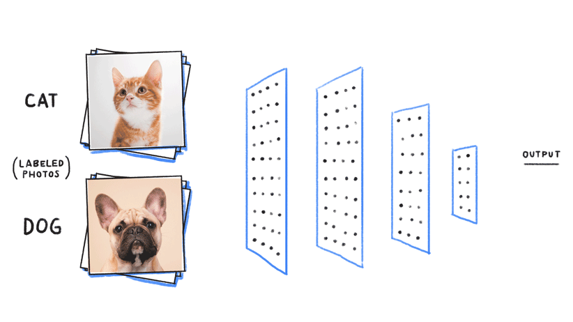

- Sequence matters

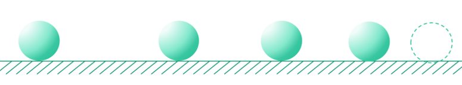

- What is a sequence?
  - sentence
  - medical signals
  - speech waveform
  - vibration measurement
- Sequence Modeling
  - Most of the real-world data is time-series
  - There are important bits to be considered
    - Past events
    - Relationship between events
      - Causality
      - Credit assignment
- Learning the structure and hierarchy
- Use the past and present observations to predict the future

# 2. (Determinstic) Sequences and Difference Equations

We will focus on linear difference equations (LDE), a surprisingly rich topic both theoretically and practivally.

For example,

$$ y[0]=1,\quad y[1]=\frac{1}{2},\quad y[2]=\frac{1}{4},\quad \cdots $$

or by closed-form expression,

$$y[n]=\left(\frac{1}{2}\right)^n,\quad n≥0 $$

or with a difference equation and an initial condition,

$$y[n]=\frac{1}{2}y[n−1],\quad y[0]=1$$

High order homogeneous LDE

$$y[n]=\alpha_1 y[n−1] + \alpha_2 y [n−2] + \cdots + \alpha_k y[n-k]$$

# 3. (Stochastic) Time Series Analysis

## 3.1. Stationarity and Non-Stationary Series

- A series is *stationary* if there is no systematic change in mean and variance over time
  - Example: radio static
- A series is *non-stationary* if mean and variance change over time
  - Example: GDP, population, weather, etc.

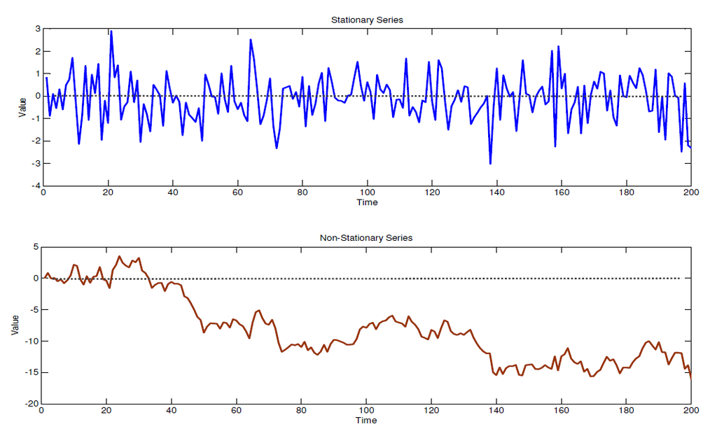

## 3.2. Dealing with Non-Stationarity

**Linear trends**

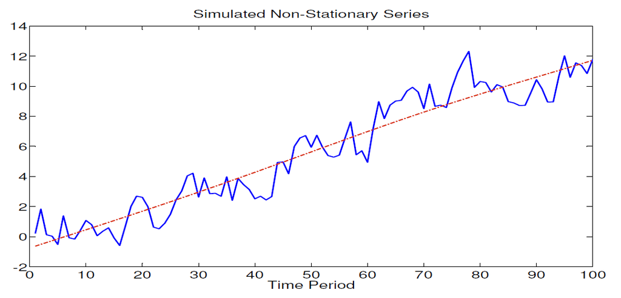

**Non-linear trends**

- For example, population may grow exponentially

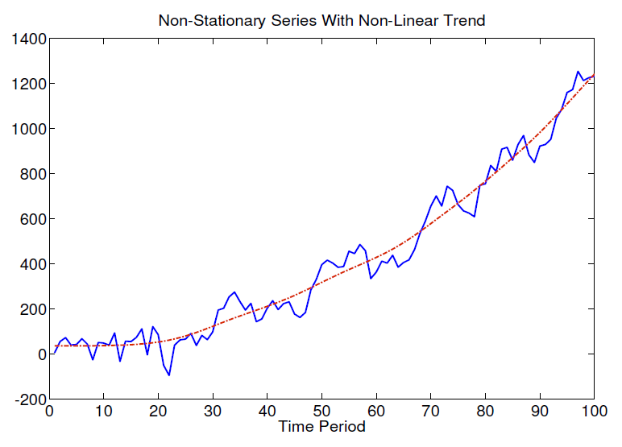

**Seasonal trends**

- Some series may exhibit seasonal trends
- For example, weather pattern, employment, inflation, etc.

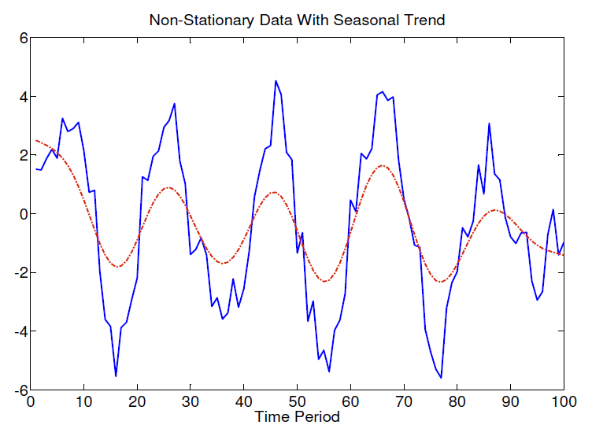

**Combining Linear, Quadratic, and Seasonal Trends**

- Some data may have a combintation of trends

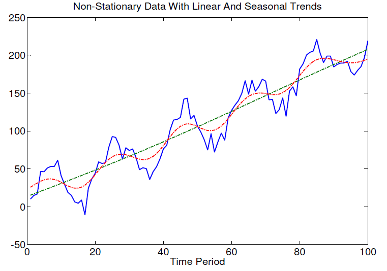

- One solution is to apply repeated differencing to the series
- For example, first remove seasonal trend. Then remove linear trend
- Inspect model fit by examining residuals Q-Q plot
- Anternatively, include both linear and cyclical trend terms into the model

\begin{align*} Y_t &= \beta_1 + \beta_2 Y_{t-1} \\ &+ \beta_3 t + \beta_4 t^{\beta_5} \\ &+ \beta_6 \sin \frac{2\pi}{s}t + \beta_7 \cos \frac{2\pi}{s}t \\ &+ u_t \end{align*}

# 4. Time-Series Data

(almost) all the data coming from manufacturing environment are time-series data

- sensor data,
- process times,
- material measurement,
- equipment maintenance history,
- image data, etc.

Manufacturing application is about one of the following:

- prediction of time-series values
- anomaly detection on time-series data
- classification of time-series values
- metrology and inspection

## 4.1. Definition of time-series

$$x: T \rightarrow \mathbb{R}^n \;\; \text{where}\;\; T=\{\cdots, t_{-2},t_{-1},t_0,t_1,t_2, \cdots \}$$

Example: material measurements: when $n=3$

$$x(t) = \begin{bmatrix} \text{average thickness}(t)\\ \text{thickness variance}(t)\\ \text{resistivity}(t) \end{bmatrix} $$

## 4.2. Supervised and Unsupervised Learning for Time-series

For supervised learning, we define two time series

$$x: T \rightarrow \mathbb{R}^n \;\; \text{and} \;\; y: T \rightarrow \mathbb{R}^m$$

Supervised time-series learning:

$$ \begin{align*} \text{predict} \quad &y(t_k) \\ \text{given} \quad & x(t_k), x(t_{k-1}), \cdots \;\, \text{and} \;\, y(t_{k-1}), y(t_{k-2}), \cdots \end{align*} $$

Unsupervised time-series anomaly detection

- Find time segment that is considerably differnt from the rest

$$ \begin{align*} \text{find} \quad & k^* \\ \text{such that} \quad & x(t_k) |_{k=k^*}^{k^*+s} \;\; \text{is significantly different from} \;\, x(t_k) |_{k=-\infty}^{\infty} \end{align*} $$

# 5. Markov Process

## 5.1. Sequential Processes

- Most classifiers ignored the sequential aspects of data
- Consider a system which can occupy one of $N$ discrete states or categories $q_t \in \{S_1,S_2,\cdots,S_N\}$
- We are interested in stochastic systems, in which state evolution is random
- Any joint distribution can be factored into a series of conditional distributions

$$p(q_0,q_1,\cdots,q_T ) = p(q_0) \; p(q_1 \mid q_0) \; p( q_2 \mid q_1 q_0 ) \; p( q_3 \mid q_2 q_1 q_0 ) \cdots$$

Amost impossible to compute !!

$$p(q_0,q_1,\cdots,q_T ) = p(q_0) \; p(q_1 \mid q_0) \; p( q_2 \mid q_1 ) \; p( q_3 \mid q_2 ) \cdots$$

Possible and tractable !!

## 5.2. Markov Process

- (Assumption) for a Markov process, the next state depends only on the current state:

$$ p(q_{t+1} \mid q_t,\cdots,q_0) = p(q_{t+1} \mid q_t)$$

- More clearly

$$ p(q_{t+1} = s_j \mid q_t = s_i) = p(q_{t+1} = s_j \mid q_t = s_i,\; \text{any earlier history})$$

- Given current state, the past does not matter
- The state captures all relevant information from the history
- The state is a sufficient statistic of the future

## 5.3. State Transition Matrix

For a Markov state 𝑠 and successor state 𝑠′, the state transition probability is defined by

$$ P_{ss'} = P\left[S_{t+1} = s' \mid S_t = s \right] $$

State transition matrix $P$ defines transition probabilities from all states $s$ to all successor states $s'$.

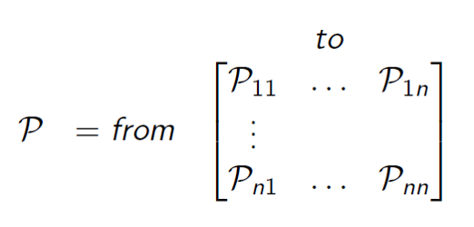

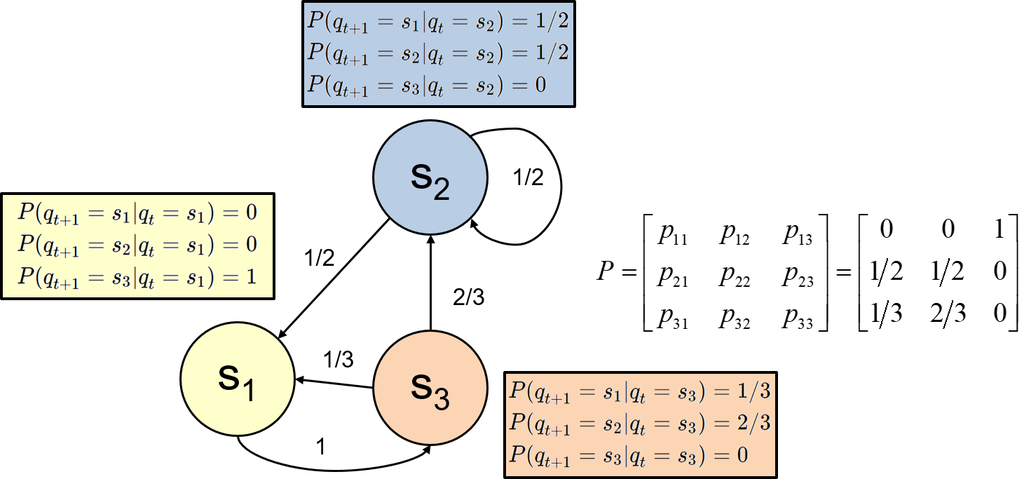

Example: MC episodes

- sample episodes starting from $S_1$

```python
import numpy as np

P = [[0, 0, 1],
    [1/2, 1/2, 0],
    [1/3, 2/3, 0]]
```

```python
print(P[1][:])
```

```
[0.5, 0.5, 0]
```

```python
a = np.random.choice(3,1,p = P[1][:])
print(a)
```

```
[1]
```

```python
# sequential processes
# sequence generated by Markov chain
# S1 = 0, S2 = 1, S3 = 2

# starting from 0
x = 0
S = []
S.append(x)

for i in range(50):
    x = np.random.choice(3,1,p = P[x][:])[0]
    S.append(x)

print(S)
```

```
[0, 2, 1, 1, 1, 0, 2, 0, 2, 0, 2, 1, 0, 2, 0, 2, 1, 1, 0, 2, 0, 2, 0, 2, 1, 0, 2, 1, 0, 2, 0, 2, 0, 2, 0, 2, 1, 1, 0, 2, 1, 1, 0, 2, 1, 0, 2, 1, 0, 2, 1]
```

# 6. Hidden Markov Models

- Discrete state-space model
  - Used in speech recognition
  - State representation is simple
  - Hard to scale-up the training
- Assumption
  - We can observe something that is affected by the true state
  - Natual way of thinking
- Limited sensors (incomplete state information)
  - But still partially related
- Noisy senors
  - Unreliable

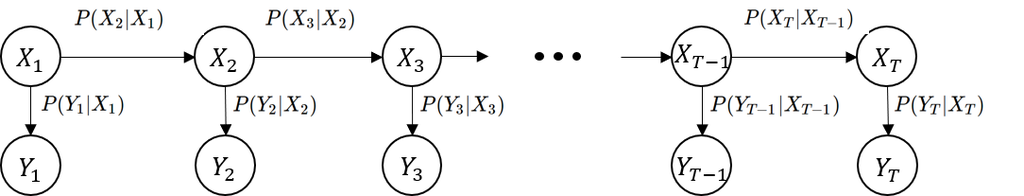

- True state (or hidden variable) follows Markov chain
- Observation emitted from state
  - $Y_t$ is noisily determined depending on the current state $X_t$
- Forward: sequence of observations can be generated
- Question: state estimation

$$P(X_T = s_i \mid Y_1 Y_2 \cdots Y_T)$$

- HMM can do this, but with many difficulties

# 7. Kalman Filter

- Linear dynamical system of motion

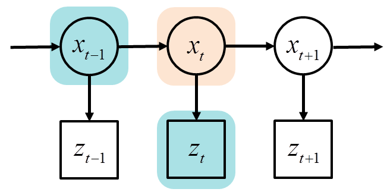

$$ \begin{align*} x_{t+1} &= A x_t + B u_t \\ z_t &= Cx_t \end{align*} $$

- A, B, C ?
- Continuous State space model
  - For filtering and control applications
  - Linear-Gaussian state space model
  - Widely used in many applications:
    - GPS, weather systems, etc.
- Weakness
  - Linear state space model assumed
  - Difficult to apply to highly non-linear domains

```python
%%javascript
$.getScript('https://kmahelona.github.io/ipython_notebook_goodies/ipython_notebook_toc.js')
```